# Analyzing plant phenology near the Santa Clara River

## Background

Phenology, referring to the timing of life events, plays a vital role in plants, encompassing processes like leaf growth, flowering, and leaf senescence. Plants adjust these events according to local climate conditions to ensure successful reproduction, while animal species often align their phenology with food availability. The ongoing climate shifts disrupt this synchronization, making alterations in phenology a crucial gauge of how ecosystems are adapting to climate change. Plant species employ diverse phenological strategies, including winter deciduous (shedding leaves in winter, regrowing in spring), drought deciduous (losing leaves in summer during water scarcity), and evergreen (maintaining leaves throughout the year).

Plants use different strategies for growth and survival: riparian forests, grasslands, and chaparral shrublands

## Goal

To examine the phenology of these plant communities, we will utilize a time series of Landsat imagery along with polygons that identify the locations of study sites within each plant community.

## Dataset

#### Landsat Operational Land Imager (OLI sensor)

8 pre-processed scenes

- Level 2 surface reflectance products
- erroneous values were set to NA
- scale factor set to 100
- bands 2-7
- dates in filenname

#### Study sites

Each identified by plant type, with the column named “study_site.”

## Highlights

- combining vector/raster data
- compute and summarize NDVI value
- map and plot algebra

## Workflow

```r
library(terra)
library(sf)
library(dplyr)
library(tidyr)
library(stringr)
library(ggplot2)
library(here)
library(tmap)
library(cowplot)

rm(list = ls())


here::i_am("phenology.Rmd")
```

### NDVI function for nir and red

This index is derived by calculating the difference in reflectance between the near-infrared and red bands and then normalizing the result by their sum.

```r
ndvi_fun = function(nir, red){
  (nir - red) / (nir + red)
}
```

## Sampling one of the scene

### Computing NDVI for a single scene

We have 8 scenes collected by the Landsat OLI sensor on 8 different days throughout the year. Let’s start by loading in the first scene collected on June 12, 2018

```r
landsat_20180612 <-rast(here("data", "landsat_20180612.tif"))

landsat_20180612
```

```
## class       : SpatRaster
## dimensions  : 284, 1314, 6  (nrow, ncol, nlyr)
## resolution  : 30, 30  (x, y)
## extent      : 314415, 353835, 3803175, 3811695  (xmin, xmax, ymin, ymax)
## coord. ref. : WGS 84 / UTM zone 11N (EPSG:32611)
## source      : landsat_20180612.tif
## names       : lands~612_1, lands~612_2, lands~612_3, lands~612_4, lands~612_5, lands~612_6
## min values  :     0.00350,      0.8725,       1.087,      1.3180,     1.12825,     1.84050
## max values  :    54.15375,     60.0855,      62.973,     70.6345,    68.01650,    92.92325
```

## Match the spectral bands

```r
names(landsat_20180612) <- c("blue", "green", "red", "NIR", "SWIR1", "SWIR2")

landsat_20180612
```

```
## class       : SpatRaster
## dimensions  : 284, 1314, 6  (nrow, ncol, nlyr)
## resolution  : 30, 30  (x, y)
## extent      : 314415, 353835, 3803175, 3811695  (xmin, xmax, ymin, ymax)
## coord. ref. : WGS 84 / UTM zone 11N (EPSG:32611)
## source      : landsat_20180612.tif
## names       :     blue,   green,    red,     NIR,    SWIR1,    SWIR2
## min values  :  0.00350,  0.8725,  1.087,  1.3180,  1.12825,  1.84050
## max values  : 54.15375, 60.0855, 62.973, 70.6345, 68.01650, 92.92325
```

### Take NIR and Red bands

Utilize the NDVI function and calculate this using the lapp() method.

```r
ndvi_20180612 <- lapp(landsat_20180612[[c(4, 3)]], fun = ndvi_fun)

ndvi_20180612
```

```
## class       : SpatRaster
## dimensions  : 284, 1314, 1  (nrow, ncol, nlyr)
## resolution  : 30, 30  (x, y)
## extent      : 314415, 353835, 3803175, 3811695  (xmin, xmax, ymin, ymax)
## coord. ref. : WGS 84 / UTM zone 11N (EPSG:32611)
## source(s)   : memory
## name        :       lyr1
## min value   : -0.4089055
## max value   :  0.9304582
```

### omputing NDVI for all scenes

Now we want to repeat the same operations for all 8 scenes. Below is a possible solution, but it’s pretty clunky. Outline our function by first specifying the operations we aim to perform, which involves creating a list of files/scenes. This list will enable our function to compute NDVI for each scene, requiring us to locate the relevant files in our data folder. Subsequently, we’ll update our function to operate seamlessly with the list of file names we generated.

```r
# bring data
files <- list.files(here("data"), pattern = "*.tif", full.names = TRUE)

files
```

```
## [1] "/Users/haejinkim/Documents/UCSB/Fall23/EDS223-geospatial/final_project/phenology/data/landsat_20180612.tif"
## [2] "/Users/haejinkim/Documents/UCSB/Fall23/EDS223-geospatial/final_project/phenology/data/landsat_20180815.tif"
## [3] "/Users/haejinkim/Documents/UCSB/Fall23/EDS223-geospatial/final_project/phenology/data/landsat_20181018.tif"
## [4] "/Users/haejinkim/Documents/UCSB/Fall23/EDS223-geospatial/final_project/phenology/data/landsat_20181103.tif"
## [5] "/Users/haejinkim/Documents/UCSB/Fall23/EDS223-geospatial/final_project/phenology/data/landsat_20190122.tif"
## [6] "/Users/haejinkim/Documents/UCSB/Fall23/EDS223-geospatial/final_project/phenology/data/landsat_20190223.tif"
## [7] "/Users/haejinkim/Documents/UCSB/Fall23/EDS223-geospatial/final_project/phenology/data/landsat_20190412.tif"
## [8] "/Users/haejinkim/Documents/UCSB/Fall23/EDS223-geospatial/final_project/phenology/data/landsat_20190701.tif"
```

```r
# now we're passing our function a number that will correspond to the index in the list of file names
create_ndvi_layer <- function(i){
  landsat <- rast(files[i])
  names(landsat) <- c("blue", "green", "red", "NIR", "SWIR1", "SWIR2")
  ndvi <- lapp(landsat[[c(4, 3)]], fun = ndvi_fun)
}
```

Employ our function to generate an NDVI layer for each scene and then combine them into a unified raster stack.

```r
# create NDVI layer for each scene (day) and stack into a single rasterstack
all_ndvi <- c(create_ndvi_layer(1),
              create_ndvi_layer(2),
              create_ndvi_layer(3),
              create_ndvi_layer(4),
              create_ndvi_layer(5),
              create_ndvi_layer(6),
              create_ndvi_layer(7),
              create_ndvi_layer(8))

# update layer names to match date
names(all_ndvi) <- c("2018-06-12",
                     "2018-08-15",
                     "2018-10-18",
                     "2018-11-03",
                     "2019-01-22",
                     "2019-02-23",
                     "2019-04-12",
                     "2019-07-01")
```

### Compare NDVI across vegetation communities

Having calculated NDVI for each of our scenes (days), our objective is to compare variations in NDVI values across distinct vegetation communities.

```r
sites <- st_read(here("data","study_sites.shp"))
sites
```

```
## Simple feature collection with 5 features and 1 field
## Geometry type: POLYGON
## Dimension:     XY
## Bounding box:  xmin: 314413.3 ymin: 3803180 xmax: 353848.7 ymax: 3811694
## Projected CRS: WGS 84 / UTM zone 11N
##   study_site                       geometry
## 1  grassland POLYGON ((342104.8 3810429,...
## 2  chaparral POLYGON ((338638.6 3805600,...
## 3    forest1 POLYGON ((314428.7 3803368,...
## 4    forest2 POLYGON ((352372.7 3811535,...
## 5    forest3 POLYGON ((343437 3807992, 3...
```

```
## Variable(s) "NA" contains positive and negative values, so midpoint is set to 0. Set midpoint = NA to show the full spectrum of the color palette.
```

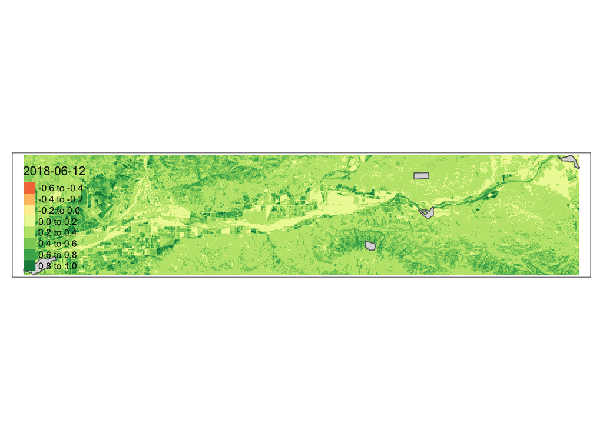

```r
# plot study sites on a single NDVI layer
tm_shape(all_ndvi[[1]]) +
  tm_raster() +
  tm_shape(sites) +
  tm_polygons()
```

In this step, we determine the average NDVI within each study site. The output of the extraction process is a data frame with rows corresponding to the study site dataset. To integrate these results, we bind them to the original dataset.

```r
sites_ndvi <- terra::extract(all_ndvi, sites, fun = "mean")

sites_annotated <- cbind(sites, sites_ndvi)
```

#### clean results

```r
sites_clean <- sites_annotated %>%
  st_drop_geometry() %>%
  select(-ID) %>%
  pivot_longer(!study_site) %>%
  rename("NDVI" = value) %>%
  mutate("year" = str_sub(name, 2, 5),
         "month" = str_sub(name, 7, 8),
         "day" = str_sub(name, -2, -1)) %>%
  unite("date", 4:6, sep = "-") %>%
  mutate("date" = lubridate::as_date(date))
```

#### plot results

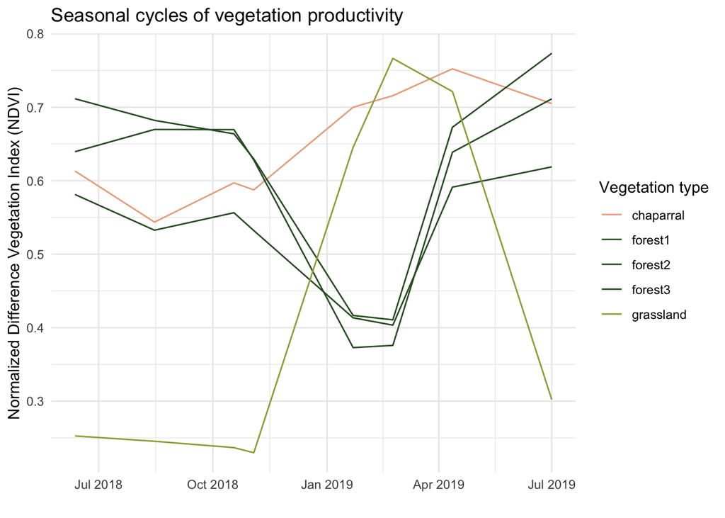

```r
ggplot(sites_clean,
       aes(x = date, y = NDVI,
           group = study_site, col = study_site)) +
  scale_color_manual(values = c("#EAAC8B", "#315C2B", "#315C2B", "#315C2B","#9EA93F")) +
  geom_line() +
  theme_minimal() +
  labs(x = "", y = "Normalized Difference Vegetation Index (NDVI)", col = "Vegetation type",
       title = "Seasonal cycles of vegetation productivity")
```

## Conclusion

This lab focuses on analyzing plant phenology near the Santa Clara River using Landsat imagery and study sites representing different vegetation communities. The workflow involves creating an NDVI function, computing NDVI for each scene, stacking them into a raster stack, and comparing NDVI changes across vegetation communities. The process is streamlined by generalizing the workflow into a function and efficiently handling multiple scenes. The study sites’ NDVI values are extracted, tidied, and visualized to observe seasonal cycles of vegetation productivity.